# IML - Homework 2

## Medical Expenditure Panel Survey

## **SHAP / Break Down**

### Import packages

```python
import pandas as pd
import numpy as np
import pickle
import matplotlib.pyplot as plt

from itertools import combinations
from sklearn.model_selection import train_test_split
from sklearn.ensemble import RandomForestRegressor, GradientBoostingRegressor
from sklearn.linear_model import LinearRegression
from sklearn.metrics import r2_score, mean_squared_error
from dalex import explainer
```

### Read and explore data

```python
data = pd.read_csv("MEPS_data_preprocessed.csv")
data.drop(columns = ["PANEL", "PERSONWT"], inplace = True)
```

```python
data.head()
```

|  | REGION | AGE31X | GENDER | RACE3 | MARRY31X | EDRECODE | FTSTU31X | ACTDTY31 | HONRDC31 | RTHLTH31 | ... | ADSMOK42 | PCS42 | MCS42 | K6SUM42 | PHQ242 | EMPST31 | POVCAT15 | INSCOV15 | INCOME_M | HEALTHEXP |
| --- | --- | --- | --- | --- | --- | --- | --- | --- | --- | --- | --- | --- | --- | --- | --- | --- | --- | --- | --- | --- | --- |
| 0 | 2 | 52 | 0.0 | 0.0 | 5 | 13 | -1 | 2 | 2 | 4 | ... | 2 | 25.93 | 58.47 | 3 | 0 | 4 | 1 | 2 | 11390.0 | 46612 |
| 1 | 2 | 55 | 1.0 | 0.0 | 3 | 14 | -1 | 2 | 2 | 4 | ... | 2 | 20.42 | 26.57 | 17 | 6 | 4 | 3 | 2 | 11390.0 | 9207 |
| 2 | 2 | 22 | 1.0 | 0.0 | 5 | 13 | 3 | 2 | 2 | 1 | ... | 2 | 53.12 | 50.33 | 7 | 0 | 1 | 2 | 2 | 18000.0 | 808 |
| 3 | 2 | 2 | 0.0 | 0.0 | 6 | -1 | -1 | 3 | 3 | 1 | ... | -1 | -1.00 | -1.00 | -1 | -1 | -1 | 2 | 2 | 385.0 | 2721 |
| 4 | 3 | 25 | 1.0 | 0.0 | 1 | 14 | -1 | 2 | 2 | 1 | ... | 2 | 59.89 | 45.91 | 9 | 2 | 1 | 3 | 1 | 3700.0 | 1573 |

5 rows × 44 columns

```python
data.shape
```

```
(18350, 44)
```

```python
# Check columns types and if there are any missing values
data.info()
```

```
<class 'pandas.core.frame.DataFrame'>
RangeIndex: 18350 entries, 0 to 18349
Data columns (total 44 columns):
 #   Column     Non-Null Count  Dtype
---  ------     --------------  -----
 0   REGION     18350 non-null  int64
 1   AGE31X     18350 non-null  int64
 2   GENDER     18350 non-null  float64
 3   RACE3      18350 non-null  float64
 4   MARRY31X   18350 non-null  int64
 5   EDRECODE   18350 non-null  int64
 6   FTSTU31X   18350 non-null  int64
 7   ACTDTY31   18350 non-null  int64
 8   HONRDC31   18350 non-null  int64
 9   RTHLTH31   18350 non-null  int64
```

[output cut: 36 more lines]

```python
# Check number of unique values in columns
num_unique = data.nunique()
num_unique
```

```
REGION          4
AGE31X         86
GENDER          2
RACE3           2
MARRY31X       10
EDRECODE        7
FTSTU31X        4
ACTDTY31        4
HONRDC31        4
RTHLTH31        6
MNHLTH31        6
HIBPDX          3
CHDDX           3
ANGIDX          3
MIDX            3
OHRTDX          3
STRKDX          3
EMPHDX          3
CHBRON31        3
CHOLDX          3
CANCERDX        3
DIABDX          3
JTPAIN31        3
ARTHDX          3
ARTHTYPE        4
ASTHDX          3
ADHDADDX        3
PREGNT31        3
WLKLIM31        3
ACTLIM31        3
SOCLIM31        3
COGLIM31        3
DFHEAR42        3
DFSEE42         3
ADSMOK42        3
PCS42        3208
MCS42        3177
K6SUM42        27
PHQ242          8
EMPST31         5
POVCAT15        5
INSCOV15        3
INCOME_M     6553
HEALTHEXP    7424
dtype: int64
```

```python
# Check descriptive statistics of target variable
data["HEALTHEXP"].describe()
```

```
count     18350.000000
mean       5184.511608
std       15126.748532
min           0.000000
25%         198.000000
50%        1034.000000
75%        4219.500000
max      659952.000000
Name: HEALTHEXP, dtype: float64
```

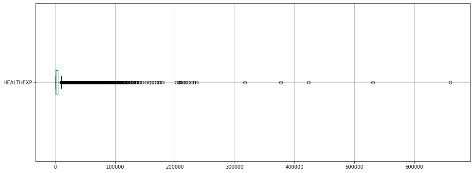

```python
# Check boxplot of target variable
plt.figure(figsize = (16, 6))
data[["HEALTHEXP"]].boxplot(vert = False)
plt.show()
```

```python
# Drop outliers - observations that has "HEALTHEXP" >= 250000
data = data.loc[data["HEALTHEXP"] < 250000, :]
```

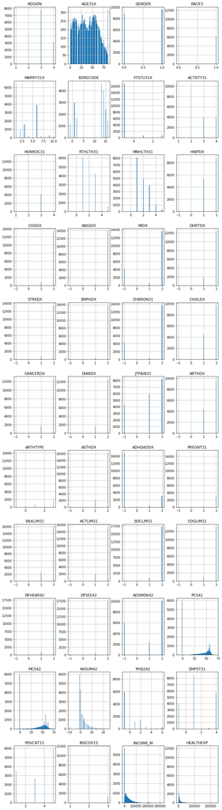

```python
# Check histograms of all variables

fig, axes = plt.subplots(11, 4, figsize = (12, 48))

i = 0
for triaxis in axes:
    for axis in triaxis:
        data.hist(column = data.columns[i], bins = 100, ax = axis)
        i = i+1

plt.show()
```

### Prepare data for modelling

```python
# Split data into train and test sets
X_train, X_test, y_train, y_test = train_test_split(data.drop(["HEALTHEXP"], axis = 1), data["HEALTHEXP"], test_size = 0.33, random_state = 123)
```

```python
# Get categorical columns (lets assume that variable is categorical if it has <= 10 unique values)
categorical_col_names = num_unique[num_unique <= 10].index
categorical_col_names
```

```
Index(['REGION', 'GENDER', 'RACE3', 'MARRY31X', 'EDRECODE', 'FTSTU31X',
       'ACTDTY31', 'HONRDC31', 'RTHLTH31', 'MNHLTH31', 'HIBPDX', 'CHDDX',
       'ANGIDX', 'MIDX', 'OHRTDX', 'STRKDX', 'EMPHDX', 'CHBRON31', 'CHOLDX',
       'CANCERDX', 'DIABDX', 'JTPAIN31', 'ARTHDX', 'ARTHTYPE', 'ASTHDX',
       'ADHDADDX', 'PREGNT31', 'WLKLIM31', 'ACTLIM31', 'SOCLIM31', 'COGLIM31',
       'DFHEAR42', 'DFSEE42', 'ADSMOK42', 'PHQ242', 'EMPST31', 'POVCAT15',
       'INSCOV15'],
      dtype='object')
```

```python
# One-hot encoding
for col in categorical_col_names:
    df_train = pd.get_dummies(X_train[col], prefix = col)
    X_train = pd.concat([X_train, df_train], axis = 1)
    df_test = pd.get_dummies(X_test[col], prefix = col)
    X_test = pd.concat([X_test, df_test], axis = 1)
```

```python
X_train = X_train.drop(categorical_col_names, axis = 1).reset_index(drop = True)
X_test = X_test.drop(categorical_col_names, axis = 1).reset_index(drop = True)
y_train = y_train.reset_index(drop = True)
y_test = y_test.reset_index(drop = True)
```

### Build model

```python
reg_rf = RandomForestRegressor(random_state = 123)
reg_rf.fit(X_train, y_train)

y_pred_train = reg_rf.predict(X_train)
y_pred_test = reg_rf.predict(X_test)

print("RandomForestRegressor")

print("Training R^2:", r2_score(y_train, y_pred_train))
print("Test R^2:", r2_score(y_test, y_pred_test))

mse_train = mean_squared_error(y_train, y_pred_train)
rmse_train = np.sqrt(mse_train)
mse_test = mean_squared_error(y_test, y_pred_test)
rmse_test = np.sqrt(mse_test)
print("Training RMSE:", rmse_train)
print("Test RMSE:", rmse_test)
```

```
RandomForestRegressor
Training R^2: 0.8244612976827861
Test R^2: 0.004297318189844801
Training RMSE: 5490.1741873171495
Test RMSE: 12650.234663536297
```

```python
y_train.describe()
```

```
count     12291.000000
mean       5083.653812
std       13104.406296
min           0.000000
25%         196.000000
50%        1020.000000
75%        4220.000000
max      236449.000000
Name: HEALTHEXP, dtype: float64
```

```python
y_test.describe()
```

```
count      6054.000000
mean       5012.438553
std       12678.550789
min           0.000000
25%         200.000000
50%        1060.500000
75%        4184.000000
max      228348.000000
Name: HEALTHEXP, dtype: float64
```

```python
reg_xgb = GradientBoostingRegressor(random_state = 123)
reg_xgb.fit(X_train, y_train)

y_pred_train2 = reg_xgb.predict(X_train)
y_pred_test2 = reg_xgb.predict(X_test)

print("GradientBoostingRegressor")

print("Training R^2:", r2_score(y_train, y_pred_train2))
print("Test R^2:", r2_score(y_test, y_pred_test2))

mse_train2 = mean_squared_error(y_train, y_pred_train2)
rmse_train2 = np.sqrt(mse_train2)
mse_test2 = mean_squared_error(y_test, y_pred_test2)
rmse_test2 = np.sqrt(mse_test2)
print("Training RMSE:", rmse_train2)
print("Test RMSE:", rmse_test2)
```

```
GradientBoostingRegressor
Training R^2: 0.35851731198598435
Test R^2: 0.19309083390463233
Training RMSE: 10495.234629128767
Test RMSE: 11387.963534405788
```

```python
for x in [10, 20, 50, 100, 110, 120, 125, 130, 135, 140, 150]:
    reg_xgb = GradientBoostingRegressor(n_estimators = x, random_state = 123)
    reg_xgb.fit(X_train, y_train)

    y_pred_train2 = reg_xgb.predict(X_train)
    y_pred_test2 = reg_xgb.predict(X_test)

    print(x)

    print("Training R^2:", r2_score(y_train, y_pred_train2))
    print("Test R^2:", r2_score(y_test, y_pred_test2))

    mse_train2 = mean_squared_error(y_train, y_pred_train2)
    rmse_train2 = np.sqrt(mse_train2)
    mse_test2 = mean_squared_error(y_test, y_pred_test2)
    rmse_test2 = np.sqrt(mse_test2)
    print("Training RMSE:", rmse_train2)
    print("Test RMSE:", rmse_test2)
```

```
10
Training R^2: 0.15558219871827628
Test R^2: 0.13413198458667652
Training RMSE: 12041.438499919728
Test RMSE: 11796.674385227838
20
Training R^2: 0.22049956254759717
Test R^2: 0.16644330573126354
Training RMSE: 11569.320796831857
Test RMSE: 11574.47537285436
50
Training R^2: 0.30094613271991677
Test R^2: 0.18680481115459024
Training RMSE: 10956.075166343438
Test RMSE: 11432.235011941928
100
Training R^2: 0.35851731198598435
Test R^2: 0.19309083390463233
Training RMSE: 10495.234629128767
Test RMSE: 11387.963534405788
110
Training R^2: 0.3716653840647338
Test R^2: 0.19200288505395857
Training RMSE: 10387.12062302527
Test RMSE: 11395.638096178105
120
Training R^2: 0.382375652175305
Test R^2: 0.19206248299152473
Training RMSE: 10298.213374777852
Test RMSE: 11395.217816798795
125
Training R^2: 0.38629560624733716
Test R^2: 0.19144598078248265
Training RMSE: 10265.480872677368
Test RMSE: 11399.564586918716
130
Training R^2: 0.3914247274182734
Test R^2: 0.19194235647026203
Training RMSE: 10222.493262147027
Test RMSE: 11396.064922526964
135
Training R^2: 0.39653413266809234
Test R^2: 0.19091519854022976
Training RMSE: 10179.490404348517
Test RMSE: 11403.305644181353
140
Training R^2: 0.39825390381993575
Test R^2: 0.19033899724074443
Training RMSE: 10164.975180519798
Test RMSE: 11407.365435008312
150
Training R^2: 0.4075463194069161
Test R^2: 0.18986629694666224
Training RMSE: 10086.18391013466
Test RMSE: 11410.694901397585
```

### 1) For the selected data set, train at least one tree-based ensemble model

```python
reg = GradientBoostingRegressor(random_state = 123)
reg.fit(X_train, y_train)
```

```
GradientBoostingRegressor(alpha=0.9, criterion='friedman_mse', init=None,
                          learning_rate=0.1, loss='ls', max_depth=3,
                          max_features=None, max_leaf_nodes=None,
                          min_impurity_decrease=0.0, min_impurity_split=None,
                          min_samples_leaf=1, min_samples_split=2,
                          min_weight_fraction_leaf=0.0, n_estimators=100,
                          n_iter_no_change=None, presort='auto',
                          random_state=123, subsample=1.0, tol=0.0001,
                          validation_fraction=0.1, verbose=0, warm_start=False)
```

```python
pickle.dump(reg, open("xgb_model.pickle", "wb"))
```

### 2) For some selected observation from this dataset, calculate the model predictions for model (1)

```python
obs = X_test.iloc[[23]]
obs_pred = reg.predict(obs)
```

### 3) For an observation selected in (2), calculate the decomposition of model prediction using SHAP, Break Down or both

```python
exp = explainer.Explainer(model = reg, data = X_train, y = y_train, model_type = "regression")
```

```
Preparation of a new explainer is initiated

  -> label             : not specified, model's class taken instead!
  -> data              : 12291 rows 148 cols
  -> target variable   :  Argument 'y' was a pandas.Series. Converted to a numpy.ndarray.
  -> target variable   : 12291 values
  -> predict function  : <function yhat.<locals>.<lambda> at 0x000001E5EC833730> will be used
  -> predicted values  : min = -1632.324312154238, mean = 5083.6538117321625, max = 180054.88162417396
  -> residual function : difference between y and yhat
  -> residuals         : min = -29227.441415995185, mean = 2.3678976858460422e-14, max = 228737.4908028723
  -> model_info        : package sklearn

A new explainer has been created!
```

```python
break_down = exp.predict_parts(obs, type = "break_down")
break_down.plot(max_vars = 20)
```

[interactive chart not shown]

```python
shap = exp.predict_parts(obs, type = "shap")
shap.plot(max_vars = 20)
```

[interactive chart not shown]

### 4) Find two observations in the data set, such that they have different most important variables

```python
obs2 = X_test.iloc[[1010]]
obs2_pred = reg.predict(obs2)

break_down2 = exp.predict_parts(obs2, type = "break_down")
break_down2.plot(max_vars = 20)
```

[interactive chart not shown]

```python
obs3 = X_test.iloc[[4040]]
obs3_pred = reg.predict(obs3)

break_down3 = exp.predict_parts(obs3, type = "break_down")
break_down3.plot(max_vars = 20)
```

[interactive chart not shown]

### 5) Select one variable and find two observations in the data set such that for one observation this variable has a positive effect and for the other a negative effect

```python
break_down.plot(max_vars = 20)
```

[interactive chart not shown]

```python
break_down3.plot(max_vars = 20)
```

[interactive chart not shown]

### 6) Train a second model (of any class, neural nets, linear, other boosting) and find an observation for which BD/shap attributions are different between the models

```python
reg_lr = LinearRegression()
reg_lr.fit(X_train, y_train)

y_pred_train = reg_lr.predict(X_train)
y_pred_test = reg_lr.predict(X_test)

print("LinearRegression")

print("Training R^2:", r2_score(y_train, y_pred_train))
print("Test R^2:", r2_score(y_test, y_pred_test))

mse_train = mean_squared_error(y_train, y_pred_train)
rmse_train = np.sqrt(mse_train)
mse_test = mean_squared_error(y_test, y_pred_test)
rmse_test = np.sqrt(mse_test)
print("Training RMSE:", rmse_train)
print("Test RMSE:", rmse_test)
```

```
LinearRegression
Training R^2: 0.20562760372174493
Test R^2: 0.19224704364233502
Training RMSE: 11679.163923408145
Test RMSE: 11393.916213090964
```

```python
pickle.dump(reg_lr, open("lr_model.pickle", "wb"))
```

```python
exp_lr = explainer.Explainer(model = reg_lr, data = X_train, y = y_train, model_type = "regression")
```

```
Preparation of a new explainer is initiated

  -> label             : not specified, model's class taken instead!
  -> data              : 12291 rows 148 cols
  -> target variable   :  Argument 'y' was a pandas.Series. Converted to a numpy.ndarray.
  -> target variable   : 12291 values
  -> predict function  : <function yhat.<locals>.<lambda> at 0x000001E5EE827378> will be used
  -> predicted values  : min = -5616.727305602988, mean = 5083.653811732161, max = 37557.96194363997
  -> residual function : difference between y and yhat
  -> residuals         : min = -30843.729257228973, mean = 1.3733806577907044e-12, max = 228979.07838358384
  -> model_info        : package sklearn

A new explainer has been created!
```

```python
obs_lr = X_test.iloc[[6042]]
obs_lr_pred = reg.predict(obs_lr)
```

```python
# Break Down for LinearRegression
break_down_lr = exp_lr.predict_parts(obs_lr, type = "break_down")
break_down_lr.plot(max_vars = 20)
```

[interactive chart not shown]

```python
# Break Down for GradientBoostingRegressor
break_down_xgb = exp.predict_parts(obs_lr, type = "break_down")
break_down_xgb.plot(max_vars = 20)
```

[interactive chart not shown]

### 7) Comment on the results for points (4), (5) and (6)

**Ad 4)** Można zauważyć, że dla dwóch wybranych obserwacji nieco inne zmienne są 'najważniejsze'. Np zmienna **PCS24** występuje jako jedna z najważniejszych dla obu obserwacji, ale na każdą z nich ma inny wpływ.

**Ad 5)** Jak widać na wykresach, zmienna **RACE3_1.0** na piewszą obserwację wpływa dodatnio, na drugą ujemnie. Na dodatek zmienna ta w obu obserwacjach przyjmuje taką samą wartość.

**Ad 6)** Atrybucje Break Down dla tej samej wybranej obserwacji różnią się pomiędzy modelami.